# Análise de Consumo de Álcool entre estudantes da UEFS

  Analisamos se as pessoas que residem com o respondente podem interferiar em seu padrão de consumo

  ```r
  tabela_moradia_vs_frequencia <- dados_brutos %>%
    filter(!is.na(MoraComQuem) & !is.na(Frequencia)) %>%
    count(MoraComQuem, Frequencia) %>%
    group_by(MoraComQuem) %>%
    mutate(
      # Percentual NUMÉRICO: para a altura das barras e cálculos
      PercentualNumerico = n / sum(n),
      # Percentual em TEXTO: para os rótulos do gráfico e tabelas
      PercentualTexto = scales::percent(PercentualNumerico, accuracy = 0.1)
    ) %>%
    ungroup() %>%
    rename(Quantidade = n)

  tabela_contingencia <- dados_brutos %>%
    count(MoraComQuem, Frequencia) %>%
    tidyr::pivot_wider(names_from = Frequencia, values_from = n, values_fill = 0)

  teste_qui_quadrado <- chisq.test(tabela_contingencia[, -1])
  cat("--- Teste Qui-Quadrado de Independência ---\n\n")
  ```

  ```
  ## --- Teste Qui-Quadrado de Independência ---
  ```

  ```r
  print(teste_qui_quadrado)
  ```

  ```
  ##
  ##  Pearson's Chi-squared test
  ##
  ## data:  tabela_contingencia[, -1]
  ## X-squared = 19.238, df = 8, p-value = 0.01364
  ```

  ```r
  cat("\n\n")
  ```

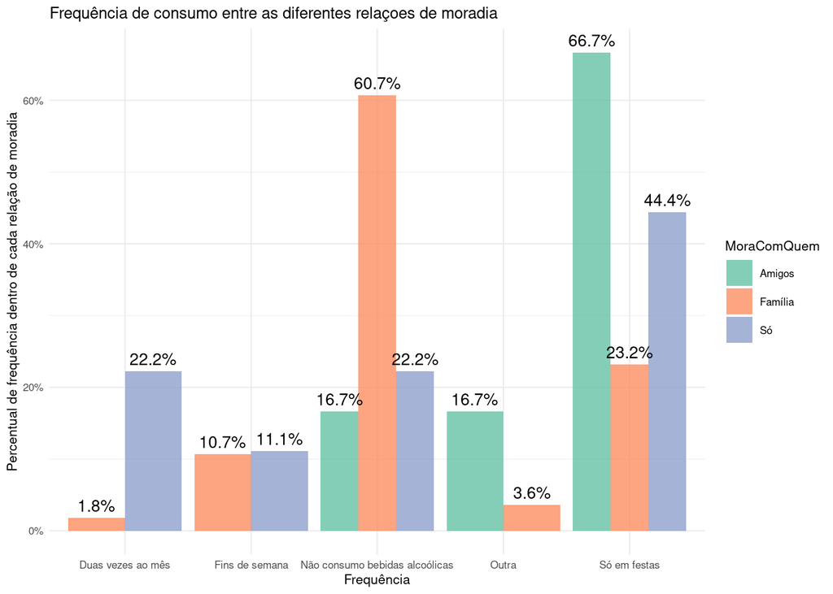

  ```r
  ggplot(tabela_moradia_vs_frequencia, aes(x = Frequencia, y = PercentualNumerico, fill = MoraComQuem)) +
    geom_bar(stat = "identity", position = "dodge", alpha = 0.8) +
    # O rótulo usa a coluna de TEXTO
    geom_text(
      aes(label = PercentualTexto),
      position = position_dodge(width = 0.9),
      vjust = -0.5,
      size = 3.5
    ) +
    #
    scale_y_continuous(labels = scales::percent_format(accuracy = 1)) +
    scale_fill_brewer(palette = "Set2") +
    labs(
      title = "Frequência de consumo entre as diferentes relaçoes de moradia",
      x = "Frequência",
      y = "Percentual de frequência dentro de cada relação de moradia",
      fill = "MoraComQuem"
    ) +
    theme_minimal(base_size = 8)
  ```

  ```r
  tabela_para_exibir <- tabela_moradia_vs_frequencia %>%
    select(MoraComQuem, `Frequencia` = Frequencia, Quantidade, Percentual = PercentualTexto)

  knitr::kable(
    tabela_para_exibir,
    caption = "Tabela de cruzamento mostrando a frequância de consumo em diferentes relações de moradia"
  )
  ```

  Tabela de cruzamento mostrando a frequância de consumo em diferentes relações de moradia

  | MoraComQuem | Frequencia | Quantidade | Percentual |
  | --- | --- | --- | --- |
  | Amigos | Não consumo bebidas alcoólicas | 1 | 16.7% |
  | Amigos | Outra | 1 | 16.7% |
  | Amigos | Só em festas | 4 | 66.7% |
  | Família | Duas vezes ao mês | 1 | 1.8% |
  | Família | Fins de semana | 6 | 10.7% |
  | Família | Não consumo bebidas alcoólicas | 34 | 60.7% |
  | Família | Outra | 2 | 3.6% |
  | Família | Só em festas | 13 | 23.2% |
  | Só | Duas vezes ao mês | 2 | 22.2% |
  | Só | Fins de semana | 1 | 11.1% |
  | Só | Não consumo bebidas alcoólicas | 2 | 22.2% |
  | Só | Só em festas | 4 | 44.4% |

Eixo 03: Influências (Causas do comportamento)

- Imagem que causa vs. Frequência

  Analisamos se a imagem que os respondentes tem em relação a bebida interfere na frequência de consumo deles

  ```r
  tabela_imagem_vs_frequencia <- dados_brutos %>%
    filter(!is.na(ImagemQueCausa) & !is.na(Frequencia)) %>%
    count(ImagemQueCausa, Frequencia) %>%
    group_by(ImagemQueCausa) %>%
    mutate(
      # Percentual NUMÉRICO: para a altura das barras e cálculos
      PercentualNumerico = n / sum(n),
      # Percentual em TEXTO: para os rótulos do gráfico e tabelas
      PercentualTexto = scales::percent(PercentualNumerico, accuracy = 0.1)
    ) %>%
    ungroup() %>%
    rename(Quantidade = n)

  tabela_contingencia <- dados_brutos %>%
    count(ImagemQueCausa, Frequencia) %>%
    tidyr::pivot_wider(names_from = Frequencia, values_from = n, values_fill = 0)

  teste_qui_quadrado <- chisq.test(tabela_contingencia[, -1])
  cat("--- Teste Qui-Quadrado de Independência ---\n\n")
  ```

  ```
  ## --- Teste Qui-Quadrado de Independência ---
  ```

  ```r
  print(teste_qui_quadrado)
  ```

  ```
  ##
  ##  Pearson's Chi-squared test
  ##
  ## data:  tabela_contingencia[, -1]
  ## X-squared = 70.49, df = 12, p-value = 2.593e-10
  ```

  ```r
  cat("\n\n")
  ```

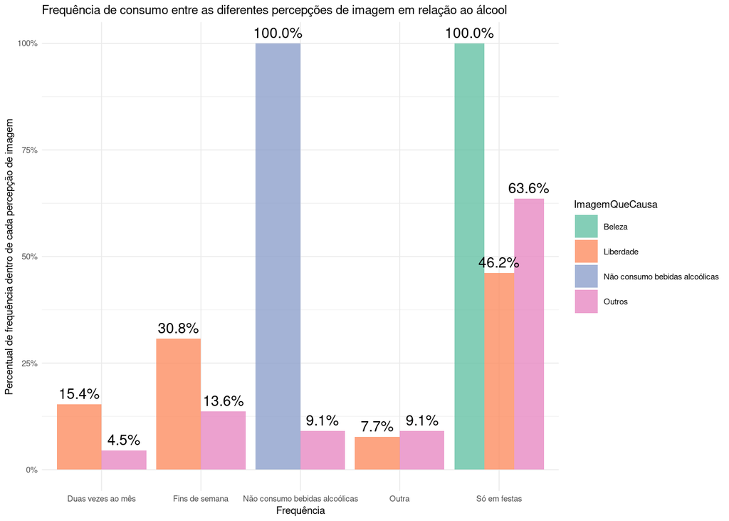

  ```r
  ggplot(tabela_imagem_vs_frequencia, aes(x = Frequencia, y = PercentualNumerico, fill = ImagemQueCausa)) +
    geom_bar(stat = "identity", position = "dodge", alpha = 0.8) +
    # O rótulo usa a coluna de TEXTO
    geom_text(
      aes(label = PercentualTexto),
      position = position_dodge(width = 0.9),
      vjust = -0.5,
      size = 3.5
    ) +

    scale_y_continuous(labels = scales::percent_format(accuracy = 1)) +
    scale_fill_brewer(palette = "Set2") +
    labs(
      title = "Frequência de consumo entre as diferentes percepções de imagem em relação ao álcool",
      x = "Frequência",
      y = "Percentual de frequência dentro de cada percepção de imagem",
      fill = "ImagemQueCausa"
    ) +
    theme_minimal(base_size = 7)
  ```

  ```r
  tabela_para_exibir <- tabela_imagem_vs_frequencia %>%
    select(ImagemQueCausa, `Frequencia` = Frequencia, Quantidade, Percentual = PercentualTexto)

  knitr::kable(
    tabela_para_exibir,
    caption = "Tabela de cruzamento mostrando a frequância de consumo em diferentes percepções de imagem em relação ao álcool"
  )
  ```

  Tabela de cruzamento mostrando a frequância de consumo em diferentes percepções de imagem em relação ao álcool

  | ImagemQueCausa | Frequencia | Quantidade | Percentual |
  | --- | --- | --- | --- |
  | Beleza | Só em festas | 1 | 100.0% |
  | Liberdade | Duas vezes ao mês | 2 | 15.4% |
  | Liberdade | Fins de semana | 4 | 30.8% |
  | Liberdade | Outra | 1 | 7.7% |
  | Liberdade | Só em festas | 6 | 46.2% |
  | Não consumo bebidas alcoólicas | Não consumo bebidas alcoólicas | 35 | 100.0% |
  | Outros | Duas vezes ao mês | 1 | 4.5% |
  | Outros | Fins de semana | 3 | 13.6% |
  | Outros | Não consumo bebidas alcoólicas | 2 | 9.1% |
  | Outros | Outra | 2 | 9.1% |
  | Outros | Só em festas | 14 | 63.6% |

- Motivo de ter começado a ingerir vs. Idade que começou

  É analisado se por exemplo, pessoas que começaram a consumir por incentivo de amigos iniciarão antes do que os de iniciativa própria

  ```r
  niveis_idade_inicio <- c(
    "Menos de 12 anos",
    "12 a 14 anos",
    "15 a 17 anos",
    "18 a 20 anos",
    "21 a 25 anos",
    "Comecei a consumir álcool recentemente (nos últimos 6 meses)",
    "Outra",
    "Não consumo bebidas alcoólicas"
  )

  # 2. Aplique esta ordem à sua coluna no data frame principal
  dados_brutos <- dados_brutos %>%
    mutate(IdadeQueComecou = factor(IdadeQueComecou, levels = niveis_idade_inicio))

  tabela_motivo_vs_idade <- dados_brutos %>%
    filter(!is.na(MotivoDoComecoNoAlcool) & !is.na(IdadeQueComecou)) %>%
    count(MotivoDoComecoNoAlcool, IdadeQueComecou) %>%
    group_by(IdadeQueComecou) %>%
    mutate(
      # Percentual NUMÉRICO: para a altura das barras e cálculos
      PercentualNumerico = n / sum(n),
      # Percentual em TEXTO: para os rótulos do gráfico e tabelas
      PercentualTexto = scales::percent(PercentualNumerico, accuracy = 0.1)
    ) %>%
    ungroup() %>%
    rename(Quantidade = n)

  tabela_contingencia <- dados_brutos %>%
    count(MotivoDoComecoNoAlcool, IdadeQueComecou) %>%
    tidyr::pivot_wider(names_from = IdadeQueComecou, values_from = n, values_fill = 0)

  teste_qui_quadrado <- chisq.test(tabela_contingencia[, -1])
  cat("--- Teste Qui-Quadrado de Independência ---\n\n")
  ```

  ```
  ## --- Teste Qui-Quadrado de Independência ---
  ```

  ```r
  print(teste_qui_quadrado)
  ```

  ```
  ##
  ##  Pearson's Chi-squared test
  ##
  ## data:  tabela_contingencia[, -1]
  ## X-squared = 75.11, df = 20, p-value = 2.612e-08
  ```

  ```r
  cat("\n\n")
  ```

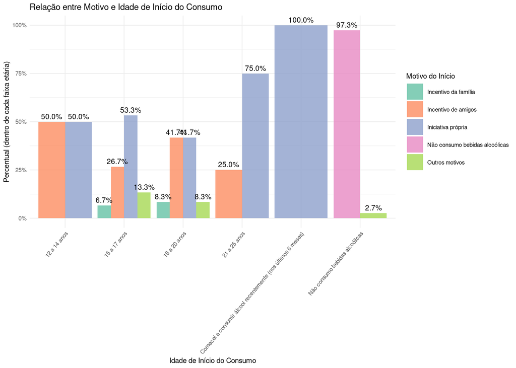

  ```r
  ggplot(tabela_motivo_vs_idade, aes(x = IdadeQueComecou, y = PercentualNumerico, fill = MotivoDoComecoNoAlcool)) +
    geom_bar(stat = "identity", position = "dodge", alpha = 0.8) +
    # O rótulo usa a coluna de TEXTO
    geom_text(
      aes(label = PercentualTexto),
      position = position_dodge(width = 0.9),
      vjust = -0.5,
      size = 2.5 # Diminuí um pouco o tamanho para não poluir
    ) +
    # O eixo y é formatado a partir dos dados NUMÉRICOS
    scale_y_continuous(labels = scales::percent_format(accuracy = 1)) +
    scale_fill_brewer(palette = "Set2") +
    labs(
      title = "Relação entre Motivo e Idade de Início do Consumo",
      x = "Idade de Início do Consumo",
      y = "Percentual (dentro de cada faixa etária)",
      fill = "Motivo do Início"
    ) +
    theme_minimal(base_size = 7) + # Aumentei um pouco a fonte base

    # --- LINHA ADICIONADA PARA CORRIGIR A SOBREPOSIÇÃO ---
    theme(axis.text.x = element_text(angle = 50, hjust = 1))
  ```

  ```r
  tabela_para_exibir <- tabela_motivo_vs_idade %>%
    select(MotivoDoComecoNoAlcool, `IdadeQueComecou` = IdadeQueComecou, Quantidade, Percentual = PercentualTexto)

  knitr::kable(
    tabela_para_exibir,
    caption = "Tabela de cruzamento mostrando o motivo do por que ter começado a ingerir bebida alcoólica e a idade em que iniciou"
  )
  ```

  Tabela de cruzamento mostrando o motivo do por que ter começado a ingerir bebida alcoólica e a idade em que iniciou

  | MotivoDoComecoNoAlcool | IdadeQueComecou | Quantidade | Percentual |
  | --- | --- | --- | --- |
  | Incentivo da família | 15 a 17 anos | 1 | 6.7% |
  | Incentivo da família | 18 a 20 anos | 1 | 8.3% |
  | Incentivo de amigos | 12 a 14 anos | 1 | 50.0% |
  | Incentivo de amigos | 15 a 17 anos | 4 | 26.7% |
  | Incentivo de amigos | 18 a 20 anos | 5 | 41.7% |
  | Incentivo de amigos | 21 a 25 anos | 1 | 25.0% |
  | Iniciativa própria | 12 a 14 anos | 1 | 50.0% |
  | Iniciativa própria | 15 a 17 anos | 8 | 53.3% |
  | Iniciativa própria | 18 a 20 anos | 5 | 41.7% |
  | Iniciativa própria | 21 a 25 anos | 3 | 75.0% |
  | Iniciativa própria | Comecei a consumir álcool recentemente (nos últimos 6 meses) | 1 | 100.0% |
  | Não consumo bebidas alcoólicas | Não consumo bebidas alcoólicas | 36 | 97.3% |
  | Outros motivos | 15 a 17 anos | 2 | 13.3% |
  | Outros motivos | 18 a 20 anos | 1 | 8.3% |
  | Outros motivos | Não consumo bebidas alcoólicas | 1 | 2.7% |

Eixo 04: Riscos e consequências

A relação entre os impactos negativos e o comportamento de consumo

- Foi protagonista de vexame por causa do álcool vs. Frequência

```r
tabela_frequencia_vs_vexame <- dados_brutos %>%
  filter(!is.na(DeuVexamePorCausaDaBebida) & !is.na(Frequencia)) %>%
  # A mudança crucial está aqui: agrupamos pela FREQUÊNCIA
  group_by(Frequencia) %>%
  # Contamos as combinações DENTRO de cada grupo de frequência
  count(DeuVexamePorCausaDaBebida) %>%
  mutate(
    PercentualNumerico = n / sum(n),
    PercentualTexto = scales::percent(PercentualNumerico, accuracy = 0.1)
  ) %>%
  ungroup() %>%
  rename(Quantidade = n)

tabela_contingencia <- dados_brutos %>%
  count(DeuVexamePorCausaDaBebida, Frequencia) %>%
  tidyr::pivot_wider(names_from = Frequencia, values_from = n, values_fill = 0)
teste_qui_quadrado <- chisq.test(tabela_contingencia[, -1])
cat("--- Teste Qui-Quadrado de Independência ---\n\n")
```

```
## --- Teste Qui-Quadrado de Independência ---
```

```r
print(teste_qui_quadrado)
```

```
##
##  Pearson's Chi-squared test
##
## data:  tabela_contingencia[, -1]
## X-squared = 29.488, df = 4, p-value = 6.221e-06
```

```r
cat("\n\n")
```

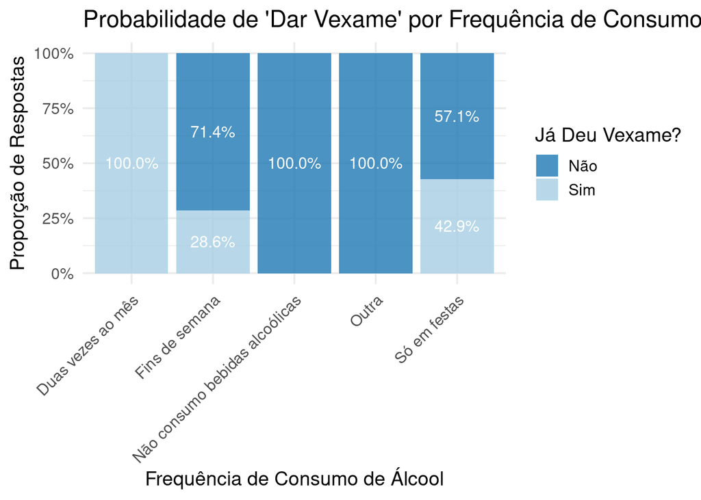

```r
ggplot(tabela_frequencia_vs_vexame, aes(x = Frequencia, y = Quantidade, fill = DeuVexamePorCausaDaBebida)) +
  geom_bar(stat = "identity", position = "fill", alpha = 0.8) +
  geom_text(
    aes(label = PercentualTexto),
    position = position_fill(vjust = 0.5),
    color = "white",
    size = 4
  ) +
  scale_y_continuous(labels = scales::percent) +
  scale_fill_brewer(palette = "Paired", direction = -1) + # Nova paleta de cores
  labs(
    title = "Probabilidade de 'Dar Vexame' por Frequência de Consumo",
    x = "Frequência de Consumo de Álcool",
    y = "Proporção de Respostas",
    fill = "Já Deu Vexame?"
  ) +
  theme_minimal(base_size = 14) +
  theme(axis.text.x = element_text(angle = 45, hjust = 1))
```

```r
knitr::kable(
  tabela_frequencia_vs_vexame,
  caption = "Tabela de cruzamento mostrando o risco de vexame por frequência de consumo."
)
```

Tabela de cruzamento mostrando o risco de vexame por frequência de consumo.

| Frequencia | DeuVexamePorCausaDaBebida | Quantidade | PercentualNumerico | PercentualTexto |
| --- | --- | --- | --- | --- |
| Duas vezes ao mês | Sim | 3 | 1.0000000 | 100.0% |
| Fins de semana | Não | 5 | 0.7142857 | 71.4% |
| Fins de semana | Sim | 2 | 0.2857143 | 28.6% |
| Não consumo bebidas alcoólicas | Não | 37 | 1.0000000 | 100.0% |
| Outra | Não | 3 | 1.0000000 | 100.0% |
| Só em festas | Não | 12 | 0.5714286 | 57.1% |
| Só em festas | Sim | 9 | 0.4285714 | 42.9% |

- Pegou carona com alguém sob efeito de álcool vs. Dirigiu sob efeito de álcool

  É análisado se o comportamento de pegar uma carona com alguém sob efeito de álcool instiga as pessoas que consomem a também dirigem sob efeito.

  ```r
  dados_consumidores <- dados_brutos %>%
    filter(RespondenteIngere == "Sim")

  tabela_carona_vs_dirigir <- dados_consumidores %>%
    filter(DirigiuSobEfeitoDoAlcool %in% c("Sim", "Não") & PegouCaronaComAlguemSobEfeitoDaBebida %in% c("Sim", "Não")) %>%

    group_by(PegouCaronaComAlguemSobEfeitoDaBebida) %>%
    count(DirigiuSobEfeitoDoAlcool) %>%
    mutate(
      PercentualNumerico = n / sum(n),
      PercentualTexto = scales::percent(PercentualNumerico, accuracy = 0.1)
    ) %>%
    ungroup() %>%
    rename(Quantidade = n)


  tabela_contingencia <- dados_consumidores %>%
    filter(DirigiuSobEfeitoDoAlcool %in% c("Sim", "Não") & PegouCaronaComAlguemSobEfeitoDaBebida %in% c("Sim", "Não")) %>%
    count(PegouCaronaComAlguemSobEfeitoDaBebida, DirigiuSobEfeitoDoAlcool) %>%
    tidyr::pivot_wider(names_from = DirigiuSobEfeitoDoAlcool, values_from = n, values_fill = 0)

  teste_qui_quadrado <- chisq.test(tabela_contingencia[, -1])
  cat("--- Teste Qui-Quadrado de Independência ---\n\n")
  ```

  ```
  ## --- Teste Qui-Quadrado de Independência ---
  ```

  ```r
  print(teste_qui_quadrado)
  ```

  ```
  ##
  ##  Pearson's Chi-squared test with Yates' continuity correction
  ##
  ## data:  tabela_contingencia[, -1]
  ## X-squared = 1.5608, df = 1, p-value = 0.2116
  ```

  ```r
  cat("\n\n")
  ```

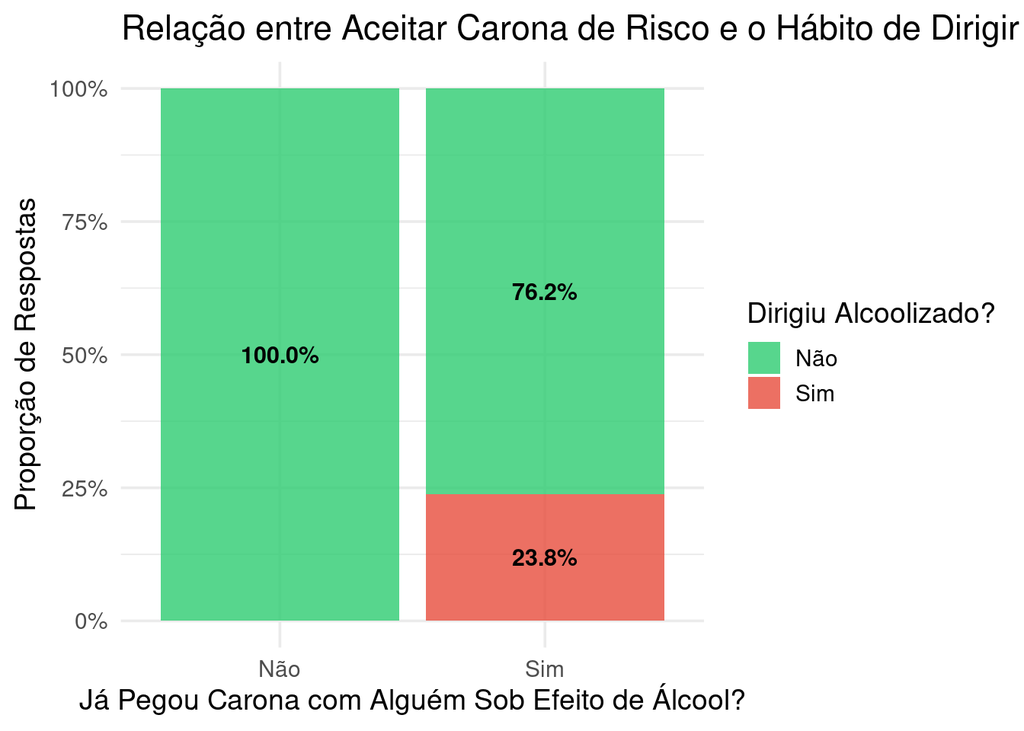

  ```r
  ggplot(tabela_carona_vs_dirigir, aes(x = PegouCaronaComAlguemSobEfeitoDaBebida, y = Quantidade, fill = DirigiuSobEfeitoDoAlcool)) +
    geom_bar(stat = "identity", position = "fill", alpha = 0.8) +
    geom_text(
      aes(label = PercentualTexto),
      position = position_fill(vjust = 0.5),
      color = "black",
      size = 4,
      fontface = "bold"
    ) +
    scale_y_continuous(labels = scales::percent) +
    scale_fill_manual(
      values = c("Não" = "#2ECC71", "Sim" = "#E74C3C"),
      name = "Dirigiu Alcoolizado?"
    ) +
    labs(
      title = "Relação entre Aceitar Carona de Risco e o Hábito de Dirigir Alcoolizado",
      x = "Já Pegou Carona com Alguém Sob Efeito de Álcool?",
      y = "Proporção de Respostas"
    ) +
    theme_minimal(base_size = 14)
  ```

  ```r
  knitr::kable(
    tabela_carona_vs_dirigir,
    caption = "Tabela de cruzamento entre o hábito de aceitar carona de risco e o de dirigir alcoolizado."
  )
  ```

  Tabela de cruzamento entre o hábito de aceitar carona de risco e o de dirigir alcoolizado.

  | PegouCaronaComAlguemSobEfeitoDaBebida | DirigiuSobEfeitoDoAlcool | Quantidade | PercentualNumerico | PercentualTexto |
  | --- | --- | --- | --- | --- |
  | Não | Não | 11 | 1.0000000 | 100.0% |
  | Sim | Não | 16 | 0.7619048 | 76.2% |
  | Sim | Sim | 5 | 0.2380952 | 23.8% |

- Respondente ingere vs. Dirigiu sob efeito de álcool

  Analisamos a proporção entre as pessoas que ingerem álcool e já dirigiram sob o efeito dele

  ```r
  dados_consumidores <- dados_brutos %>%
    filter(RespondenteIngere == "Sim")

  niveis_idade_inicio <- c("Menos de 12 anos", "12 a 14 anos", "15 a 17 anos", "18 a 20 anos", "21 a 25 anos", "Comecei a consumir álcool recentemente (nos últimos 6 meses)", "Outra")
  niveis_frequencia <- c("Fins de semana", "Três vezes ao mês", "Duas vezes ao mês", "Só em festas", "Outra", "Não consumo bebidas alcoólicas")

  dados_brutos <- dados_brutos %>%
    mutate(
      IdadeQueComecou = factor(IdadeQueComecou, levels = niveis_idade_inicio),
      Frequencia = factor(Frequencia, levels = niveis_frequencia)
    )

  dados_consumidores <- dados_consumidores %>%
    mutate(
      IdadeQueComecou = factor(IdadeQueComecou, levels = niveis_idade_inicio),
      Frequencia = factor(Frequencia, levels = niveis_frequencia)
    )

  # --- CÁLCULO
  tabela_risco_dirigir <- dados_consumidores %>%
    filter(!is.na(DirigiuSobEfeitoDoAlcool) & DirigiuSobEfeitoDoAlcool %in% c("Sim", "Não")) %>%

    count(DirigiuSobEfeitoDoAlcool, sort = TRUE) %>%
    mutate(
      PercentualNumerico = n / sum(n),
      PercentualTexto = scales::percent(PercentualNumerico, accuracy = 0.1)
    ) %>%
    rename(Resposta = DirigiuSobEfeitoDoAlcool, Quantidade = n)


  # --- GRÁFICO
  cat("### Gráfico: Proporção de Consumidores que Já Dirigiram Alcoolizados\n")
  ```

  ```
  ## ### Gráfico: Proporção de Consumidores que Já Dirigiram Alcoolizados
  ```

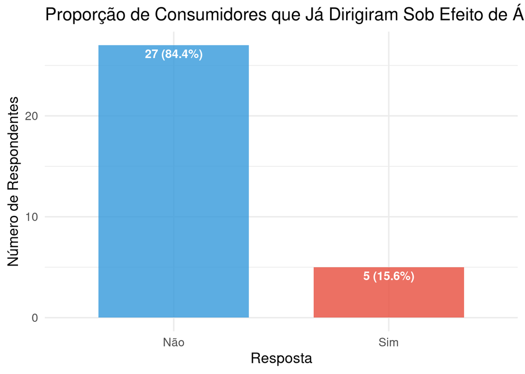

  ```r
  ggplot(tabela_risco_dirigir, aes(x = Resposta, y = Quantidade, fill = Resposta)) +
    geom_bar(stat = "identity", alpha = 0.8, width = 0.7) +

    geom_text(
      aes(label = paste0(Quantidade, " (", PercentualTexto, ")")),
      vjust = 1.5,
      color = "white",
      size = 4,
      fontface = "bold"
    ) +

    scale_fill_manual(values = c("Não" = "#3498DB", "Sim" = "#E74C3C")) +
    labs(
      title = "Proporção de Consumidores que Já Dirigiram Sob Efeito de Álcool",
      x = "Resposta",
      y = "Número de Respondentes"
    ) +
    theme_minimal(base_size = 14) +
    theme(legend.position = "none")
  ```

  ```r
  # --- TABELA
  cat("\n\n### Tabela: Proporção de Consumidores que Já Dirigiram Alcoolizados\n")
  ```

  ```
  ##
  ##
  ## ### Tabela: Proporção de Consumidores que Já Dirigiram Alcoolizados
  ```

  ```r
  knitr::kable(
    tabela_risco_dirigir,
    caption = "Distribuição de respondentes consumidores de álcool segundo o hábito de dirigir após beber."
  )
  ```

  Distribuição de respondentes consumidores de álcool segundo o hábito de dirigir após beber.

  | Resposta | Quantidade | PercentualNumerico | PercentualTexto |
  | --- | --- | --- | --- |
  | Não | 27 | 0.84375 | 84.4% |
  | Sim | 5 | 0.15625 | 15.6% |

#### Análise numérica descritiva

Mudanças necessárias para que faixa etária se torne numérica

```r
# Carregar os pacotes necessários
library(stringr)

# Recalcula o data frame usando a correção rowwise()
dados_com_idade_numerica <- dados_brutos %>%
  rowwise() %>% # <-- A correção
  mutate(
    IdadeNumerica = case_when(
      str_detect(FaixaEtaria, "Menos de") ~ 17.0,
      str_detect(FaixaEtaria, "Acima de") ~ 41.0,
      str_detect(FaixaEtaria, " a ") ~ {
        numeros <- as.numeric(unlist(str_extract_all(FaixaEtaria, "\\d+")))
        mean(numeros, na.rm = TRUE)
      },
      TRUE ~ NA_real_
    )
  ) %>%
  ungroup() %>%
  filter(!is.na(IdadeNumerica))

# Este bloco usa o objeto recém-criado para mostrar o mapeamento
tabela_mapeamento_idade <- dados_com_idade_numerica %>%
  select(FaixaEtaria, IdadeNumerica) %>%
  distinct() %>%
  arrange(IdadeNumerica) %>%
  rename(
    `Faixa Etária Original` = FaixaEtaria,
    `Valor Numérico Atribuído` = IdadeNumerica
  )

# Apresenta a tabela, que agora estará correta
knitr::kable(
  tabela_mapeamento_idade,
  caption = "Mapeamento das Faixas Etárias para Valores Numéricos (Versão Corrigida)"
)
```

Mapeamento das Faixas Etárias para Valores Numéricos (Versão Corrigida)

| Faixa Etária Original | Valor Numérico Atribuído |
| --- | --- |
| Menos de 18 anos | 17 |
| 18 a 20 anos | 19 |
| 21 a 23 anos | 22 |
| 24 a 26 anos | 25 |
| 27 a 29 anos | 28 |

Cálculo estatística descritiva

```r
# Cálculo da Média, Mediana e Quartis
estatisticas_idade <- dados_com_idade_numerica %>%
  summarise(
    Media = mean(IdadeNumerica),
    Mediana = median(IdadeNumerica),
    Q1 = quantile(IdadeNumerica, 0.25),
    Q3 = quantile(IdadeNumerica, 0.75),
    IIQ = Q3 - Q1
  )

# Cálculo da Moda (o valor mais frequente)
moda_idade <- dados_com_idade_numerica %>%
  count(IdadeNumerica, sort = TRUE) %>%
  # Pega o primeiro valor da tabela ordenada, que é o mais frequente
  slice(1) %>%
  pull(IdadeNumerica)

# Apresentar os resultados de forma organizada
cat("--- Análise Descritiva da Idade dos Respondentes ---\n")
```

```
## --- Análise Descritiva da Idade dos Respondentes ---
```

```r
cat(sprintf("Média de Idade: %.2f anos\n", estatisticas_idade$Media))
```

```
## Média de Idade: 21.46 anos
```

```r
cat(sprintf("Mediana (idade central): %.2f anos\n", estatisticas_idade$Mediana))
```

```
## Mediana (idade central): 22.00 anos
```

```r
cat(sprintf("Moda (idade mais comum): %.2f anos\n", moda_idade))
```

```
## Moda (idade mais comum): 19.00 anos
```

```r
cat("\n--- Quartis ---\n")
```

```
##
## --- Quartis ---
```

```r
cat(sprintf("Primeiro Quartil (Q1 - 25%% mais novos): %.2f anos\n", estatisticas_idade$Q1))
```

```
## Primeiro Quartil (Q1 - 25% mais novos): 19.00 anos
```

```r
cat(sprintf("Terceiro Quartil (Q3 - 75%% mais novos): %.2f anos\n", estatisticas_idade$Q3))
```

```
## Terceiro Quartil (Q3 - 75% mais novos): 22.00 anos
```

```r
cat(sprintf("Intervalo Interquartil (IIQ - 50%% centrais): %.2f anos\n", estatisticas_idade$IIQ))
```

```
## Intervalo Interquartil (IIQ - 50% centrais): 3.00 anos
```

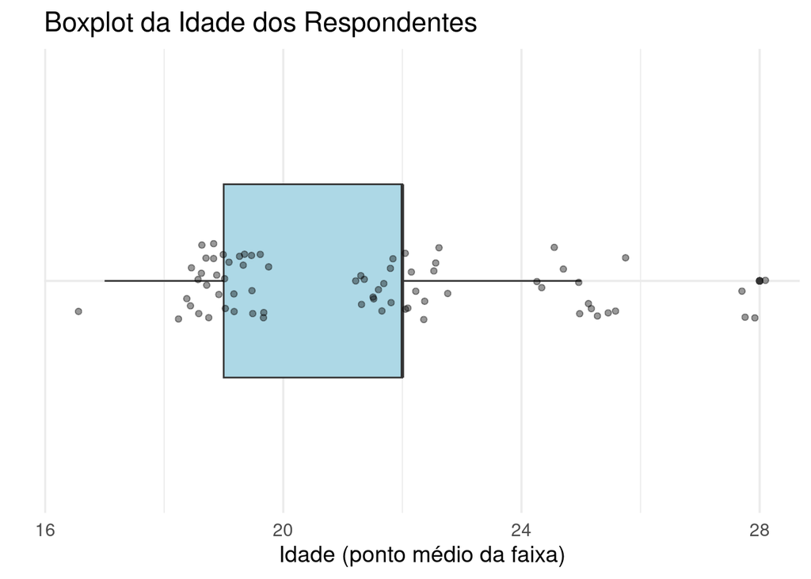

```r
ggplot(dados_com_idade_numerica, aes(x = "", y = IdadeNumerica)) + # x="" cria um boxplot vertical único
  geom_boxplot(fill = "lightblue", width = 0.5) +
  # Adiciona os pontos de dados individuais de forma transparente para ver a distribuição
  geom_jitter(width = 0.1, alpha = 0.4) +
  coord_flip() + # Deita o boxplot na horizontal
  labs(
    title = "Boxplot da Idade dos Respondentes",
    x = "", # Remove o rótulo do eixo x
    y = "Idade (ponto médio da faixa)"
  ) +
  theme_minimal(base_size = 14) +
  theme(axis.text.y = element_blank(), axis.ticks.y = element_blank()) # Remove o texto do eixo y
```